# Practical Machine Learning Project

Carlos Guardia

# Introduction

In this work (see the paper) we first define quality of execution and investigate three aspects that pertain to qualitative activity recognition: the problem of specifying correct execution, the automatic and robust detection of execution mistakes, and how to provide feedback on the quality of execution to the user. We tried out an on-body sensing approach (dataset here), but also an “ambient sensing approach” (by using Microsoft Kinect - dataset still unavailable)

Six young health participants were asked to perform one set of 10 repetitions of the Unilateral Dumbbell Biceps Curl in five different fashions: exactly according to the specification (Class A), throwing the elbows to the front (Class B), lifting the dumbbell only halfway (Class C), lowering the dumbbell only halfway (Class D) and throwing the hips to the front (Class E).

Class A corresponds to the specified execution of the exercise, while the other 4 classes correspond to common mistakes.

# Getting the Data

## Initializations

```r
rm(list = ls(all = TRUE))
setwd("c:/carlos/cursosJH/practmachinelearn/ejercicios/")
library(caret)
set.seed(37777)
```

## Data loading

Loading the data previously downloaded from the following url: https://d396qusza40orc.cloudfront.net/predmachlearn/pml-training.csv

```r
dat <- read.csv(file="pml-training.csv",sep=",",header=TRUE, na.strings=c("","NA","#DIV/0!"))
summary(dat)
```

```
##        X            user_name    raw_timestamp_part_1 raw_timestamp_part_2
##  Min.   :    1   adelmo  :3892   Min.   :1.322e+09    Min.   :   294
##  1st Qu.: 4906   carlitos:3112   1st Qu.:1.323e+09    1st Qu.:252912
##  Median : 9812   charles :3536   Median :1.323e+09    Median :496380
##  Mean   : 9812   eurico  :3070   Mean   :1.323e+09    Mean   :500656
##  3rd Qu.:14717   jeremy  :3402   3rd Qu.:1.323e+09    3rd Qu.:751891
##  Max.   :19622   pedro   :2610   Max.   :1.323e+09    Max.   :998801
##
##           cvtd_timestamp  new_window    num_window      roll_belt
##  28/11/2011 14:14: 1498   no :19216   Min.   :  1.0   Min.   :-28.90
##  05/12/2011 11:24: 1497   yes:  406   1st Qu.:222.0   1st Qu.:  1.10
##  30/11/2011 17:11: 1440               Median :424.0   Median :113.00
##  05/12/2011 11:25: 1425               Mean   :430.6   Mean   : 64.41
##  02/12/2011 14:57: 1380               3rd Qu.:644.0   3rd Qu.:123.00
##  02/12/2011 13:34: 1375               Max.   :864.0   Max.   :162.00
##  (Other)         :11007
##    pitch_belt          yaw_belt       total_accel_belt kurtosis_roll_belt
##  Min.   :-55.8000   Min.   :-180.00   Min.   : 0.00    Min.   :-2.121
##  1st Qu.:  1.7600   1st Qu.: -88.30   1st Qu.: 3.00    1st Qu.:-1.329
##  Median :  5.2800   Median : -13.00   Median :17.00    Median :-0.899
##  Mean   :  0.3053   Mean   : -11.21   Mean   :11.31    Mean   :-0.220
##  3rd Qu.: 14.9000   3rd Qu.:  12.90   3rd Qu.:18.00    3rd Qu.:-0.219
##  Max.   : 60.3000   Max.   : 179.00   Max.   :29.00    Max.   :33.000
##                                                        NA's   :19226
##  kurtosis_picth_belt kurtosis_yaw_belt skewness_roll_belt
##  Min.   :-2.190      Mode:logical      Min.   :-5.745
##  1st Qu.:-1.107      NA's:19622        1st Qu.:-0.444
##  Median :-0.151                        Median : 0.000
##  Mean   : 4.334                        Mean   :-0.026
##  3rd Qu.: 3.178                        3rd Qu.: 0.417
##  Max.   :58.000                        Max.   : 3.595
##  NA's   :19248                         NA's   :19225
##  skewness_roll_belt.1 skewness_yaw_belt max_roll_belt     max_picth_belt
##  Min.   :-7.616       Mode:logical      Min.   :-94.300   Min.   : 3.00
##  1st Qu.:-1.114       NA's:19622        1st Qu.:-88.000   1st Qu.: 5.00
##  Median :-0.068                         Median : -5.100   Median :18.00
##  Mean   :-0.296                         Mean   : -6.667   Mean   :12.92
##  3rd Qu.: 0.661                         3rd Qu.: 18.500   3rd Qu.:19.00
##  Max.   : 7.348                         Max.   :180.000   Max.   :30.00
##  NA's   :19248                          NA's   :19216     NA's   :19216
```

[output cut: 313 more lines]

```
##  Min.   :-446.00   Min.   :-1280.0   Min.   :-896.0   Min.   :-973.0
##  1st Qu.:-182.00   1st Qu.: -616.0   1st Qu.:   2.0   1st Qu.: 191.0
##  Median : -39.00   Median : -378.0   Median : 591.0   Median : 511.0
##  Mean   : -55.29   Mean   : -312.6   Mean   : 380.1   Mean   : 393.6
##  3rd Qu.:  26.00   3rd Qu.:  -73.0   3rd Qu.: 737.0   3rd Qu.: 653.0
##  Max.   : 291.00   Max.   :  672.0   Max.   :1480.0   Max.   :1090.0
##
##  classe
##  A:5580
##  B:3797
##  C:3422
##  D:3216
##  E:3607
##
##
```

## Data splitting

We will split the data into two different datasets, one for training (70% of total data) and one for testing (the rest 30%)

```r
g <- createDataPartition(y=dat$classe, p=0.7, list=FALSE)
# subset data to training
train <- dat[g,]
# subset data (the rest) to test
test <- dat[-g,]
# dimension of original and training dataset
rbind("original dataset" = dim(dat),"training set" = dim(train),"testing set" = dim(test))
```

```
##                   [,1] [,2]
## original dataset 19622  160
## training set     13737  160
## testing set       5885  160
```

# Data Cleansing

## Removing columns with NA values

```r
trainC <- train[, colSums(is.na(train)) == 0]
testC <- test[, colSums(is.na(test)) == 0]
# dimension of original and training dataset
rbind("training set" = dim(trainC),"testing set" = dim(testC))
```

```
##               [,1] [,2]
## training set 13737   60
## testing set   5885   60
```

## Removing near zero variables

```r
zvar <- nearZeroVar(trainC,saveMetrics=TRUE)
trainC <- trainC[,zvar$nzv==FALSE]
zvar <- nearZeroVar(testC,saveMetrics=TRUE)
testC <- testC[,zvar$nzv==FALSE]
# dimension of original and training dataset
rbind("training set" = dim(trainC),"testing set" = dim(testC))
```

```
##               [,1] [,2]
## training set 13737   59
## testing set   5885   59
```

## Removing meaningless variables

We need to use data closely linked to what we need to predict, so we’ll get rid of meaningless data.

```r
## Removing the timestamp columns
z <- which(grepl("timestamp", names(trainC)))
trainC <- trainC[c(-z)]
testC <- testC[c(-z)]
## Removing the window column
z <- which(grepl("window", names(trainC)))
trainC <- trainC[c(-z)]
testC <- testC[c(-z)]
# Removing the row id column
trainC <- trainC[-1]
testC <- testC[-1]
# dimension of  training  & test dataset
rbind("training set" = dim(trainC),"testing set" = dim(testC))
```

```
##               [,1] [,2]
## training set 13737   54
## testing set   5885   54
```

# Cross validation

We will split the training set into 2 separate sets for cross validation as a train control method

```r
g <- createDataPartition(y=trainC$classe, p=0.8, list=FALSE)
# subset data to training
trainCV <- trainC[g,]
# subset data (the rest) to test
validCV <- trainC[-g,]
# dimension of training and validation dataset
rbind("training cross-valid dataset" = dim(trainCV),"validation set" = dim(validCV))
```

```
##                               [,1] [,2]
## training cross-valid dataset 10991   54
## validation set                2746   54
```

# Model training

## Random Forest Model

We will be suing Random Forest to fit our model because its high accuracy rate due to its robustness in presence of outliers and covariates and its ability to select bthe meaningful variables. We will use 5-fold cross validation.

```r
Sys.time()
```

```
## [1] "2015-05-19 20:06:00 CEST"
```

```r
fitControl <- trainControl(## 5-fold CV
                           method = "repeatedcv",
                           number = 5,
                           ## repeated three times
                           repeats = 3,
                           classProbs=TRUE)
modelFit <- train(trainCV$classe ~., data=trainCV, method="rf", trControl=fitControl)
Sys.time()
```

```
## [1] "2015-05-19 20:36:17 CEST"
```

```r
modelFit
```

```
## Random Forest
##
## 10991 samples
##    53 predictor
##     5 classes: 'A', 'B', 'C', 'D', 'E'
##
## No pre-processing
## Resampling: Cross-Validated (5 fold, repeated 3 times)
##
## Summary of sample sizes: 8794, 8792, 8791, 8794, 8793, 8793, ...
##
## Resampling results across tuning parameters:
##
##   mtry  Accuracy   Kappa      Accuracy SD  Kappa SD
##    2    0.9868376  0.9833469  0.002812843  0.003560102
##   29    0.9872620  0.9838839  0.002989561  0.003784941
##   57    0.9772842  0.9712591  0.004149046  0.005254048
##
## Accuracy was used to select the optimal model using  the largest value.
## The final value used for the model was mtry = 29.
```

```r
modelFit$finalModel
```

```
##
## Call:
##  randomForest(x = x, y = y, mtry = param$mtry)
##                Type of random forest: classification
##                      Number of trees: 500
## No. of variables tried at each split: 29
##
##         OOB estimate of  error rate: 1.05%
## Confusion matrix:
##      A    B    C    D    E class.error
## A 3121    2    2    0    0 0.001280000
## B   27 2085   15    0    0 0.019746121
## C    0   15 1891   11    0 0.013562859
## D    2    0   25 1773    2 0.016093230
## E    0    2    4    8 2006 0.006930693
```

## Random Forest Model with PCA

We will also try a model based on Principal Components Analysis to check if we can improve the model accuracy and reduce the model computation time. To do so, we first need to defactorize the user_name variable into 6 indicator variables.

```r
# Defactorizing the user name variable
trainPCA <- trainCV
dum <- dummyVars(~ user_name, data=trainPCA)
t2 <- predict(dum, newdata=trainPCA)
for (i in 1:dim(t2)[2]) { n <- names(t2[1,][i]); trainPCA[,n]<- t2[,i]}
# Eliminate factor user_name column
trainPCA <- trainPCA[-1]
```

We will do a PCA analysis on the train data to check how many PCA components would be needed in order to get a good accuracy of the new model.

```r
# PCA analysis
u<-prcomp(trainPCA[-53])
summary(u)
```

```
## Importance of components:
##                             PC1      PC2      PC3      PC4       PC5
## Standard deviation     602.8751 533.9996 468.6714 375.9180 356.68368
## Proportion of Variance   0.2664   0.2090   0.1610   0.1036   0.09324
## Cumulative Proportion    0.2664   0.4754   0.6363   0.7399   0.83315
##                              PC6       PC7       PC8       PC9      PC10
## Standard deviation     255.40675 201.11411 173.22521 157.68232 119.58320
## Proportion of Variance   0.04781   0.02964   0.02199   0.01822   0.01048
## Cumulative Proportion    0.88096   0.91060   0.93259   0.95081   0.96129
##                            PC11     PC12     PC13     PC14     PC15
## Standard deviation     97.95505 90.42799 76.09583 68.58031 63.06675
## Proportion of Variance  0.00703  0.00599  0.00424  0.00345  0.00291
## Cumulative Proportion   0.96833  0.97432  0.97856  0.98201  0.98492
##                            PC16     PC17     PC18     PC19     PC20
## Standard deviation     57.11379 53.30036 50.22060 48.65494 41.35420
## Proportion of Variance  0.00239  0.00208  0.00185  0.00173  0.00125
## Cumulative Proportion   0.98732  0.98940  0.99125  0.99298  0.99423
##                            PC21     PC22    PC23     PC24     PC25    PC26
## Standard deviation     37.98715 35.28448 32.9640 30.61395 25.24534 23.3667
## Proportion of Variance  0.00106  0.00091  0.0008  0.00069  0.00047  0.0004
## Cumulative Proportion   0.99529  0.99620  0.9970  0.99769  0.99815  0.9986
##                            PC27     PC28     PC29     PC30     PC31
## Standard deviation     21.55476 21.00598 17.40167 14.94091 14.09810
## Proportion of Variance  0.00034  0.00032  0.00022  0.00016  0.00015
## Cumulative Proportion   0.99890  0.99922  0.99944  0.99960  0.99975
##                           PC32    PC33    PC34    PC35    PC36    PC37
## Standard deviation     9.99330 7.57896 7.35183 6.63327 6.16180 3.75174
## Proportion of Variance 0.00007 0.00004 0.00004 0.00003 0.00003 0.00001
## Cumulative Proportion  0.99982 0.99987 0.99990 0.99994 0.99996 0.99998
##                           PC38    PC39  PC40  PC41  PC42   PC43   PC44
## Standard deviation     3.50050 3.33428 2.119 1.933 1.125 0.5058 0.4013
## Proportion of Variance 0.00001 0.00001 0.000 0.000 0.000 0.0000 0.0000
## Cumulative Proportion  0.99998 0.99999 1.000 1.000 1.000 1.0000 1.0000
##                          PC45   PC46   PC47   PC48   PC49   PC50   PC51
## Standard deviation     0.3573 0.3204 0.3172 0.2428 0.1926 0.1862 0.1248
## Proportion of Variance 0.0000 0.0000 0.0000 0.0000 0.0000 0.0000 0.0000
## Cumulative Proportion  1.0000 1.0000 1.0000 1.0000 1.0000 1.0000 1.0000
##                          PC52    PC53    PC54    PC55    PC56    PC57
## Standard deviation     0.1045 0.06353 0.05731 0.03677 0.02708 0.01562
## Proportion of Variance 0.0000 0.00000 0.00000 0.00000 0.00000 0.00000
## Cumulative Proportion  1.0000 1.00000 1.00000 1.00000 1.00000 1.00000
##                            PC58
## Standard deviation     4.45e-14
## Proportion of Variance 0.00e+00
## Cumulative Proportion  1.00e+00
```

```r
head(unclass(u$rotation)[, 1:5])
```

```
##                            PC1           PC2           PC3           PC4
## roll_belt        -1.180855e-03  2.891389e-02 -4.371302e-02  4.096934e-02
## pitch_belt       -1.206806e-03  1.226901e-03 -2.202100e-02 -7.106168e-03
## yaw_belt          3.625953e-03  2.978554e-02  2.158990e-03  5.919082e-02
## total_accel_belt  1.426677e-05  3.735997e-03 -6.231063e-03  5.257152e-03
## gyros_belt_x     -2.917694e-06 -5.956309e-05  3.475796e-04 -2.560418e-06
## gyros_belt_y     -2.990364e-06  3.057005e-06  5.925374e-05  3.943777e-05
##                            PC5
## roll_belt        -4.379044e-02
## pitch_belt        8.395115e-04
## yaw_belt         -4.387922e-02
## total_accel_belt -4.763161e-03
## gyros_belt_x     -8.911473e-05
## gyros_belt_y     -4.312568e-05
```

As we can see, with 15 PCA components we can explain the 98.5% of the accumulated variance, so we’ll take this number to use it in our model (pcaComp=15).

```r
# Model training
Sys.time()
```

```
## [1] "2015-05-19 20:36:19 CEST"
```

```r
fitControl <- trainControl(## 5-fold CV
                           method = "repeatedcv",
                           number = 5,
                           ## repeated three times
                           repeats = 3,
                           classProbs=TRUE)
preP <- preProcess(trainPCA[,-53], method="pca", pcaComp=15, trControl=fitControl)
traPC <- predict(preP,trainPCA[,-53], trControl=fitControl)
modelFitPCA <- train(trainPCA$classe ~., data=traPC, method="rf", trControl=fitControl)
Sys.time()
```

```
## [1] "2015-05-19 20:46:09 CEST"
```

```r
modelFitPCA
```

```
## Random Forest
##
## 10991 samples
##    14 predictor
##     5 classes: 'A', 'B', 'C', 'D', 'E'
##
## No pre-processing
## Resampling: Cross-Validated (5 fold, repeated 3 times)
##
## Summary of sample sizes: 8793, 8794, 8792, 8792, 8793, 8793, ...
##
## Resampling results across tuning parameters:
##
##   mtry  Accuracy   Kappa      Accuracy SD  Kappa SD
##    2    0.9489272  0.9353755  0.005242884  0.006630261
##    8    0.9422852  0.9269773  0.004389853  0.005551744
##   15    0.9334594  0.9158053  0.005154757  0.006519013
##
## Accuracy was used to select the optimal model using  the largest value.
## The final value used for the model was mtry = 2.
```

As we can see, the maximum accuracy of the PCA model is 0.9489272, lower than the one we got without PCA. The Random Forest model is build using 14 predictors from 159 initial potential predictors.

We will be using the modelFit for validation and testing.

## Model Validation

We will validate the accuracy of our model using the validation set. We expect our model out of sample error to be less than 3% and we will estimate the error appropriately with cross-validation and accept the model if the error is lower than 3%.

```r
preVal <- predict(modelFit, validCV)
cM_VA <- confusionMatrix(validCV$classe, preVal)
cM_VA
```

```
## Confusion Matrix and Statistics
##
##           Reference
## Prediction   A   B   C   D   E
##          A 780   1   0   0   0
##          B   2 528   1   0   0
##          C   0   3 475   1   0
##          D   0   0   6 444   0
##          E   0   0   1   3 501
##
## Overall Statistics
##
##                Accuracy : 0.9934
##                  95% CI : (0.9897, 0.9961)
##     No Information Rate : 0.2848
##     P-Value [Acc > NIR] : < 2.2e-16
##
##                   Kappa : 0.9917
##  Mcnemar's Test P-Value : NA
##
## Statistics by Class:
##
##                      Class: A Class: B Class: C Class: D Class: E
## Sensitivity            0.9974   0.9925   0.9834   0.9911   1.0000
## Specificity            0.9995   0.9986   0.9982   0.9974   0.9982
## Pos Pred Value         0.9987   0.9944   0.9916   0.9867   0.9921
## Neg Pred Value         0.9990   0.9982   0.9965   0.9983   1.0000
## Prevalence             0.2848   0.1937   0.1759   0.1631   0.1824
## Detection Rate         0.2840   0.1923   0.1730   0.1617   0.1824
## Detection Prevalence   0.2844   0.1934   0.1744   0.1639   0.1839
## Balanced Accuracy      0.9985   0.9956   0.9908   0.9942   0.9991
```

```r
eose <- 1 - as.numeric(confusionMatrix(validCV$classe, preVal)$overall[1])
```

The model with the validation set has a very good accuracy (0.993445). The estimated out-of-sample error is 0.6554989%, much lower than 3%, so we accept the model.

We canm see that the model gives a worng prediction in only 18 cases out of 2746.

## Model testing

We will validate the accuracy of our model using the test set:

```r
preTest  <- predict(modelFit, testC)
cM_TE <- confusionMatrix(testC$classe, preTest)
cM_TE
```

```
## Confusion Matrix and Statistics
##
##           Reference
## Prediction    A    B    C    D    E
##          A 1672    0    1    0    1
##          B   10 1123    4    2    0
##          C    0    6 1017    3    0
##          D    0    1   20  942    1
##          E    0    1    2    7 1072
##
## Overall Statistics
##
##                Accuracy : 0.99
##                  95% CI : (0.9871, 0.9924)
##     No Information Rate : 0.2858
##     P-Value [Acc > NIR] : < 2.2e-16
##
##                   Kappa : 0.9873
##  Mcnemar's Test P-Value : NA
##
## Statistics by Class:
##
##                      Class: A Class: B Class: C Class: D Class: E
## Sensitivity            0.9941   0.9929   0.9741   0.9874   0.9981
## Specificity            0.9995   0.9966   0.9981   0.9955   0.9979
## Pos Pred Value         0.9988   0.9860   0.9912   0.9772   0.9908
## Neg Pred Value         0.9976   0.9983   0.9944   0.9976   0.9996
## Prevalence             0.2858   0.1922   0.1774   0.1621   0.1825
## Detection Rate         0.2841   0.1908   0.1728   0.1601   0.1822
## Detection Prevalence   0.2845   0.1935   0.1743   0.1638   0.1839
## Balanced Accuracy      0.9968   0.9948   0.9861   0.9915   0.9980
```

```r
eoseT <- 1 - as.numeric(confusionMatrix(testC$classe, preTest)$overall[1])
```

The model with the test set also shows a very good accuracy (0.9899745). The estimated out-of-sample error is: 1.0025489%.

# Predicting the values for the test data

Loading the exercise verification data previously downloaded from the following url: https://d396qusza40orc.cloudfront.net/predmachlearn/pml-testing.csv

```r
datTest <- read.csv(file="pml-testing.csv",sep=",",header=TRUE, na.strings=c("","NA","#DIV/0!"))
k<- names(testC)
datTest <- datTest[, names(datTest) %in% k]
# Predicted values
pred <- predict(modelFit, datTest)
pred
```

```
##  [1] B A B A A E D B A A B C B A E E A B B B
## Levels: A B C D E
```

```r
# Generate de required files
answers = rep("A", 20)
pml_write_files = function(x){
  n = length(x)
  for(i in 1:n){
    filename = paste0("problem_id_",i,".txt")
    write.table(x[i],file=filename,quote=FALSE,row.names=FALSE,col.names=FALSE)
  }
}
pml_write_files(pred)
```

# Appendix: Figures

## Plot of model Error vs Number of trees

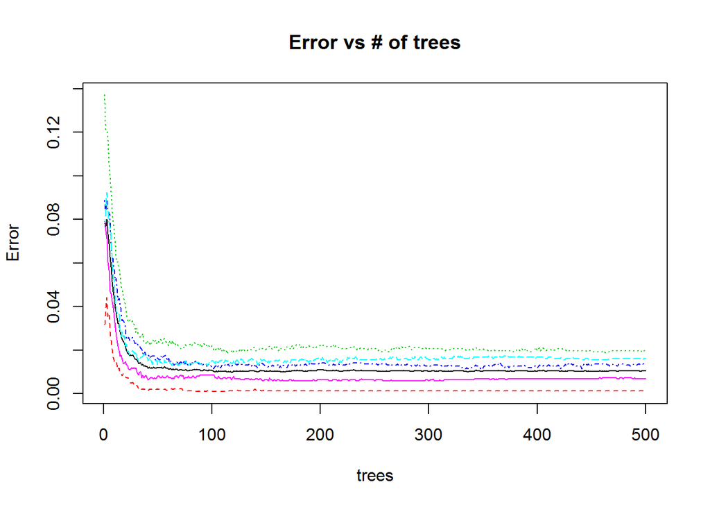

```r
plot(modelFit$finalModel, main="Error vs # of trees")
```

## Plot of model Accuracy vs Number of predictors

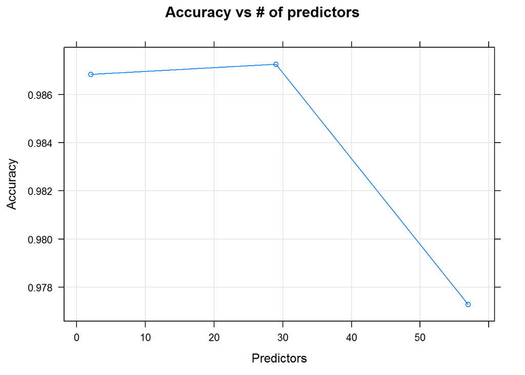

```r
plot(modelFit, main="Accuracy vs # of predictors", xlab="Predictors", ylab="Accuracy")
```